# Landfills’ impact on wealth and child health

Author

Sarah Zeller

Published

March 6, 2023

To assess the impact of landfills, I built a dataset with data from

- DHS,
- Waste Atlas,
- Ground Work and
- Open Street Maps.

This report examines how living close to landfills impacts households’ child health and their wealth index. I run regressions with varying combinations of inner and outer radius. The results for the dependent variable are shown in a plot and for all variables in a table. You can pick the dependent variable and robustness check you want to inspect.

When the treatment group exceeds 80% of the population, I do not show the regression. I did not run regressions for certain combinations of inner and outer radius, which are shown as grey-shaded part of the plot.

For *children health variables*, the following applies: The dependent variables are calculated as average per household. The diarrhoea, fever and cough rates apply to the two weeks before the survey. The mortality rate and mean birth weight apply to the five years prior to the survey.

## Selection

Choose the regression you want to inspect 👀:

[interactive chart not shown]

## Plot

[interactive chart not shown]

## Table

[interactive chart not shown]

## Inner and outer radius

The variable of interest for my regressions is whether households live close to a landfill. However, I am not sure what the right definition for “close” is: 3km, 4km, 5km? I call this distance the “inner radius”. Therefore, I simply use many definitions based on varying inner radii, and run one regression for each definition. The inner radius is shown in Figure 1.

Additionally, I cannot include the whole population in my regression. There are two reasons:

1. **The households should be comparable.**  
   Thus, they should not be too far away from each other.
2. **I do not have complete data on landfills.**  
   However, most landfills are mapped together with others.  
   Thus, when I am closer to one landfill, I can be more certain that there is no missed landfill.  
   The farther I move away from any landfill, the higher the probability that there is a landfill here, which simply was not mapped in my data set.

But here again, I am unsure what the exact cut-off value should be: should the households live within 10km of a landfill? 20? 30? I call this cut-off value the “outer radius”. As with the inner radius, I simply use many outer radii. The outer radius is also shown in Figure 1.

In the Plot, I only show the treatment dummy and its significance. I show it for each combination of inner and outer radius.

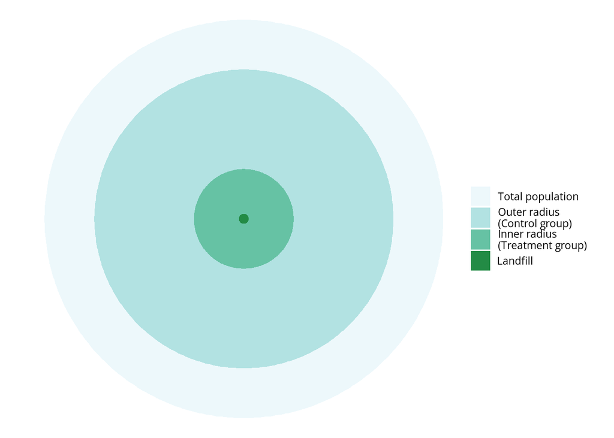

Figure 1: Sketch of inner and outer radius